# Two Definitions of Need

The legacy SHAP axis against the winners’-recipe target, across 10 technologies × 5 capability clusters

Author

Net Zero Industrial Policy Lab (NZIPL) · Johns Hopkins SAIS

Published

August 5, 2026

```r
library(readr); library(dplyr); library(tidyr); library(tibble)
library(ggplot2); library(knitr); library(showtext); library(forcats); library(arrow)
font_add_google("Archivo", "Archivo"); showtext_auto(); showtext_opts(dpi = 200)

NZ_DARK <- "#073309"
CATS  <- c("Chemicals","Electronics","Industrial Materials","Machinery","Metals")
SHORT <- c(Chemicals="Chem", Electronics="Elec", "Industrial Materials"="Ind.M",
           Machinery="Mach", Metals="Met")
TECHS <- c("Solar","Wind","Batteries","Nuclear","Geothermal","Heat Pumps",
           "Electrolyzers","Transmission","Magnets","Biofuel")

# Two-series categorical palette. Validated with the dataviz six-checks script:
# all pass (CVD ΔE 28.7 deutan, normal-vision 33.9, no contrast warning). Indigo is
# used for the legacy axis rather than a blue, to avoid reading across to the
# Chemicals category colour (#2563eb) that appears on the x axis.
MODEL_COL <- c(`Legacy SHAP axis` = "#6366f1", `Winners' recipe` = "#16a34a")

theme_nr <- function(...) theme_minimal(base_family = "Archivo", base_size = 12) +
  theme(plot.title      = element_text(size = 14, face = "bold", colour = NZ_DARK),
        plot.subtitle   = element_text(size = 10.5, colour = "#475569"),
        plot.title.position = "plot",
        panel.grid.minor   = element_blank(),
        panel.grid.major.x = element_blank(),
        panel.grid.major.y = element_line(colour = "grey92", linewidth = .3),
        axis.ticks = element_blank(), ...)
theme_set(theme_nr())
```

**The question.** The project has **two** definitions of what a technology “needs”, built from different quantities, and both are still in the repo. This document puts them side by side for all 10 technologies and measures the gap.

**Bottom line.** They disagree by a median of **15.1 percentage points** of the need profile and name a **different dominant capability for 5 of 10 technologies**. Solar is the widest — the legacy axis calls it a Chemicals problem, the winners’ recipe calls it Electronics.

# 1 What is being compared

Both definitions produce the same object: a five-number profile per technology, one number per capability cluster, normalised to sum to 100. They differ in *what they average and over whom*.

|  | **Legacy SHAP axis** | **Winners’ recipe** |
| --- | --- | --- |
| Quantity | z-scored mean **absolute** SHAP | mean **signed** SHAP, positive part |
| Population | **all** country-years in the panel | only country-years with **RCA > 1** |
| Reads as | “how much this code moves the model, anywhere” | “what the countries that actually won have” |
| Ships in | `shap_category` shares, PC scatter | `capability_gap.qmd`’s `target_weight` |
| Source | `shap_replication_by_category.csv` | `shap_replication_by_class.csv` |

The winners’ recipe replaced the legacy axis in July as the definition of need. The replacement was deliberate and documented; what was never measured is **how far the two actually sit apart**.

**Data.** Both come from the same from-source replication run (`scripts/ml/regen_shap.py`), so the comparison is like for like. `data/pc/pc_features.csv` is **not** used: it disagrees with that replication at r = 0.76 over what should be the identical quantity, with 45 rows having no counterpart at all. That staleness is a separate finding — see the register.

```r
# Winners' recipe — reproduces the shipped `target_weight` exactly (checked below)
win <- read_csv(here::here("analysis/ml/shap_replication_by_class.csv"), show_col_types = FALSE) |>
  filter(retained, category %in% CATS, tech %in% TECHS) |>
  group_by(tech, category) |>
  summarise(w = sum(pmax(mean_shap_comp, 0)), .groups = "drop") |>
  complete(tech, category = CATS, fill = list(w = 0)) |>
  group_by(tech) |> mutate(`Winners' recipe` = w/sum(w)*100) |> ungroup()

# Legacy z axis — as shipped
leg <- read_csv(here::here("analysis/ml/shap_replication_by_category.csv"), show_col_types = FALSE) |>
  filter(tech %in% TECHS) |> select(tech, category, `Legacy SHAP axis` = pct_shipped_sum_z)

need <- win |> select(tech, category, `Winners' recipe`) |>
  left_join(leg, by = c("tech","category")) |>
  mutate(`Legacy SHAP axis` = coalesce(`Legacy SHAP axis`, 0),
         tech = factor(tech, TECHS), category = factor(category, CATS))

# reconstruction check: does the winners' branch equal the shipped target_weight?
recon <- read_csv(here::here("analysis/ml/shap_gap_by_country_cluster.csv"), show_col_types = FALSE) |>
  distinct(tech, cluster, target_weight) |>
  inner_join(win |> transmute(tech, cluster = as.character(category), w), by = c("tech","cluster"))
```

The winners’ branch above reproduces the shipped `target_weight` for all 50 technology × cluster pairs to **2.2e-16** — floating-point identity, so this is the shipped target rather than a re-specification of it.

# 2 The two profiles, technology by technology

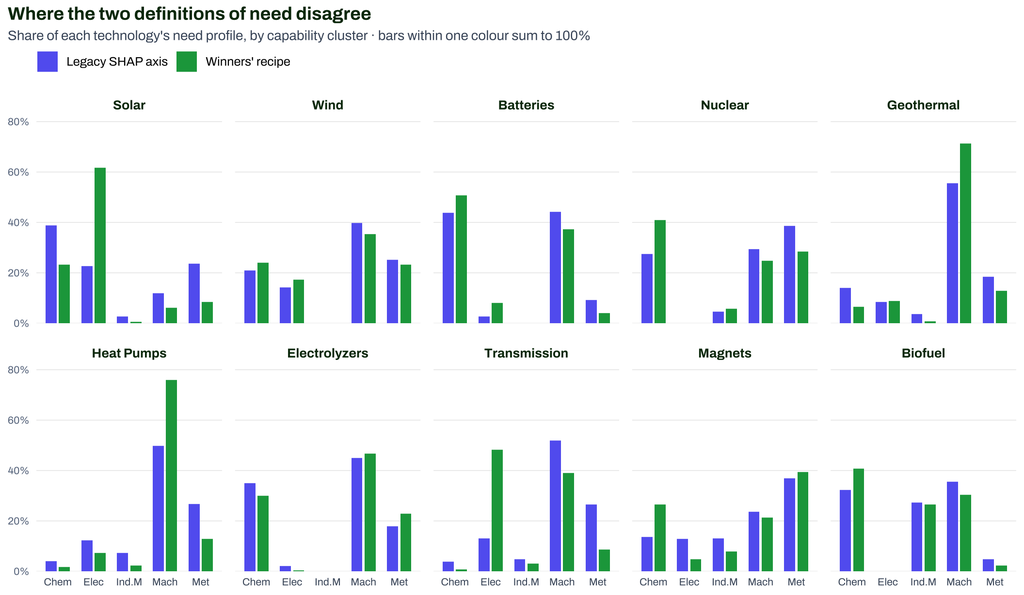

Each technology’s need profile under both definitions. Bars are the share of that technology’s need attributed to each capability cluster; the five bars of one colour sum to 100 within each panel.

```r
lng <- need |>
  pivot_longer(c(`Legacy SHAP axis`, `Winners' recipe`),
               names_to = "model", values_to = "pct") |>
  mutate(model = factor(model, names(MODEL_COL)),
         cshort = factor(SHORT[as.character(category)], unname(SHORT[CATS])))

ggplot(lng, aes(cshort, pct, fill = model)) +
  geom_col(position = position_dodge(width = .74), width = .62) +
  scale_fill_manual(values = MODEL_COL, name = NULL) +
  scale_y_continuous(expand = expansion(mult = c(0, .08)), labels = \(x) paste0(x, "%")) +
  facet_wrap(~tech, ncol = 5) +
  labs(title = "Where the two definitions of need disagree",
       subtitle = "Share of each technology's need profile, by capability cluster · bars within one colour sum to 100%",
       x = NULL, y = NULL) +
  theme(legend.position = "top",
        legend.justification = "left",
        legend.margin = margin(b = 4),
        strip.text = element_text(face = "bold", colour = NZ_DARK, size = 10),
        axis.text.x = element_text(size = 8, colour = "#475569"),
        axis.text.y = element_text(size = 8, colour = "#64748b"),
        panel.spacing.x = unit(10, "pt"), panel.spacing.y = unit(14, "pt"))
```

```r
tops <- need |> group_by(tech) |>
  summarise(leg = as.character(category[which.max(`Legacy SHAP axis`)]),
            win = as.character(category[which.max(`Winners' recipe`)]), .groups = "drop")
topcount <- tops |> pivot_longer(c(leg, win), names_to = "model", values_to = "top") |>
  count(model, top) |> pivot_wider(names_from = model, values_from = n, values_fill = 0)
```

**Machinery loses the top slot; Chemicals and Electronics take it.** Which capability each definition calls the biggest need:

```r
kable(topcount |> transmute(Capability = top,
                            `Top under legacy` = leg, `Top under winners' recipe` = win) |>
        arrange(desc(`Top under legacy`)),
      caption = "Number of technologies for which each capability is the largest need.")
```

Number of technologies for which each capability is the largest need.

| Capability | Top under legacy | Top under winners’ recipe |
| --- | --- | --- |
| Machinery | 7 | 4 |
| Metals | 2 | 1 |
| Chemicals | 1 | 3 |
| Electronics | 0 | 2 |

Machinery falls from **7 of 10** technologies to **4**. Machinery holds the most HS codes of any cluster, and the legacy axis — a sum of z-scores — rewards a cluster for holding many codes.

**Two technologies barely move at all.** Wind and Electrolyzers agree on shape and on top axis under both definitions — there, the choice is immaterial.

# 3 One number per technology: TVD

To summarise a whole panel in a single figure, use **total variation distance** — half the sum of absolute differences across the five axes:

$$\text{TVD} \;=\; \tfrac{1}{2}\sum_{c \in \text{clusters}} \bigl| \text{legacy}_c - \text{winners}_c \bigr|$$

Because both profiles sum to 100, TVD reads directly as **“how many percentage points of the need profile would have to be moved to turn one into the other”**. 0 means the two definitions agree exactly; 100 would mean they share no capability at all. It is the summary of exactly what the bars above show.

```r
tvd <- need |> group_by(tech) |>
  summarise(TVD = sum(abs(`Legacy SHAP axis` - `Winners' recipe`))/2,
            `Largest single-axis shift` = max(abs(`Legacy SHAP axis` - `Winners' recipe`)),
            `Top axis — legacy`  = as.character(category[which.max(`Legacy SHAP axis`)]),
            `Top axis — winners` = as.character(category[which.max(`Winners' recipe`)]),
            .groups = "drop") |>
  mutate(Flip = ifelse(`Top axis — legacy` != `Top axis — winners`, "yes", "—")) |>
  arrange(desc(TVD))
kable(tvd, digits = 1, col.names = c("Technology","TVD (pp)","Largest single-axis shift (pp)",
                                     "Top axis — legacy","Top axis — winners","Top axis flips"),
      caption = "How far apart the two definitions of need sit, per technology.")
```

How far apart the two definitions of need sit, per technology.

| Technology | TVD (pp) | Largest single-axis shift (pp) | Top axis — legacy | Top axis — winners | Top axis flips |
| --- | --- | --- | --- | --- | --- |
| Solar | 38.9 | 38.9 | Chemicals | Electronics | yes |
| Transmission | 35.1 | 35.1 | Machinery | Electronics | yes |
| Heat Pumps | 26.1 | 26.1 | Machinery | Machinery | — |
| Geothermal | 16.2 | 15.8 | Machinery | Machinery | — |
| Magnets | 15.5 | 12.9 | Metals | Metals | — |
| Nuclear | 14.8 | 13.6 | Metals | Chemicals | yes |
| Batteries | 12.3 | 7.0 | Machinery | Chemicals | yes |
| Biofuel | 8.4 | 8.4 | Machinery | Chemicals | yes |
| Electrolyzers | 6.7 | 5.1 | Machinery | Machinery | — |
| Wind | 6.3 | 4.5 | Machinery | Machinery | — |

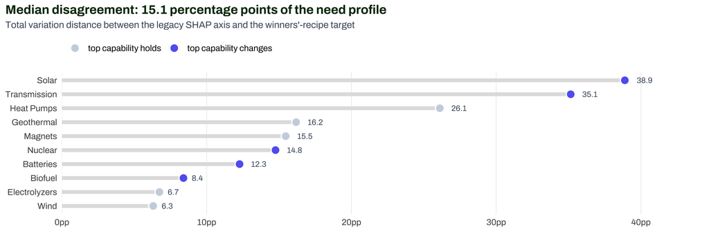

The same TVD figures ranked. Filled markers are technologies where the two definitions also name a different dominant capability.

```r
ggplot(tvd |> mutate(tech = fct_reorder(tech, TVD)), aes(TVD, tech)) +
  geom_segment(aes(x = 0, xend = TVD, yend = tech), colour = "grey88", linewidth = 2) +
  geom_point(aes(fill = Flip == "yes"), shape = 21, size = 4, stroke = 1,
             colour = "white") +
  scale_fill_manual(values = c(`TRUE` = "#6366f1", `FALSE` = "#cbd5e1"),
                    labels = c(`TRUE` = "top capability changes", `FALSE` = "top capability holds"),
                    name = NULL) +
  geom_text(aes(label = sprintf("%.1f", TVD)), hjust = -0.75,
            family = "Archivo", size = 3.1, colour = "#475569") +
  scale_x_continuous(expand = expansion(mult = c(0, .14)), labels = \(x) paste0(x, "pp")) +
  labs(title = "Median disagreement: 15.1 percentage points of the need profile",
       subtitle = "Total variation distance between the legacy SHAP axis and the winners'-recipe target",
       x = NULL, y = NULL) +
  theme(legend.position = "top", legend.justification = "left",
        panel.grid.major.y = element_blank(),
        panel.grid.major.x = element_line(colour = "grey92", linewidth = .3))
```

Median **15.1 pp**, range 6.3–38.9 pp, and the dominant capability changes for **5 of 10** technologies. Solar and Transmission are the two technologies where a reader would draw a materially different conclusion about what to build.

# 4 Does it change the recommendation?

TVD measures the profiles. Whether that *matters* depends on whether the movement crosses a decision boundary — so here it is run through the seven-cell priority grid, which combines the need share with the country’s own RCA. Only the need axis changes between the two runs; the RCA is identical.

```r
classify <- function(sp, r) case_when(
  sp >= 25 & r >= 1 ~ "Leverage",  sp >= 25 & r >= .5 ~ "Build-up", sp >= 25 ~ "Critical gap",
  sp >= 10 & r >= 1 ~ "Mature",    sp >= 10 & r >= .5 ~ "Build-up", sp >= 10 ~ "Gap",
  r >= 1 ~ "Bonus", TRUE ~ "Not priority")

rcaP <- read_parquet(here::here("data/pc/pc_rca.parquet")); YRP <- max(rcaP$year, na.rm = TRUE)
reg  <- read_csv(here::here("data/case_registry.csv"), show_col_types = FALSE) |> filter(kind == "country")

cells <- rcaP |> filter(category %in% CATS, tech %in% TECHS, year == YRP) |>
  select(iso3, country, tech, category, rca) |>
  inner_join(need |> mutate(tech = as.character(tech), category = as.character(category)),
             by = c("tech","category")) |>
  mutate(cell_leg = classify(`Legacy SHAP axis`, rca),
         cell_win = classify(`Winners' recipe`, rca),
         moved    = cell_leg != cell_win)
cellsR <- cells |> filter(iso3 %in% reg$iso3)

kable(cellsR |> group_by(Technology = tech) |>
        summarise(Cells = n(), Changed = sum(moved), .groups = "drop") |>
        mutate(`% changed` = Changed/Cells*100) |> arrange(desc(`% changed`)),
      digits = 1,
      caption = sprintf("Country × capability cells that change priority classification when the need definition is swapped — %d CVCE-roster countries, RCA year %d.",
                        n_distinct(cellsR$iso3), YRP))
```

Country × capability cells that change priority classification when the need definition is swapped — 27 CVCE-roster countries, RCA year 2024.

| Technology | Cells | Changed | % changed |
| --- | --- | --- | --- |
| Solar | 135 | 96 | 71.1 |
| Magnets | 135 | 81 | 60.0 |
| Heat Pumps | 135 | 51 | 37.8 |
| Transmission | 135 | 46 | 34.1 |
| Geothermal | 135 | 27 | 20.0 |
| Nuclear | 108 | 21 | 19.4 |
| Wind | 135 | 18 | 13.3 |
| Batteries | 135 | 0 | 0.0 |
| Biofuel | 108 | 0 | 0.0 |
| Electrolyzers | 108 | 0 | 0.0 |

**26.8% of roster cells change their priority classification** on identical trade data. But the effect is a **threshold** effect, not a smooth one, and that is the important part: Solar changes 71% of its cells and Magnets 60%, while **Batteries, Biofuel and Electrolyzers change none at all** despite moving 12.3, 8.4 and 6.7 pp. Their movement never crosses the grid’s 10% or 25% cut points.

**So TVD does not predict impact.** It measures how far the definitions sit apart; whether that distance costs anything depends on where the cut points fall. Both numbers are needed.

```r
kable(cellsR |> filter(moved) |> count(`Under legacy` = cell_leg, `Under winners' recipe` = cell_win,
                                       sort = TRUE, name = "Cells") |> head(6),
      caption = "The most common reclassifications.")
```

The most common reclassifications.

| Under legacy | Under winners’ recipe | Cells |
| --- | --- | --- |
| Gap | Not priority | 81 |
| Critical gap | Gap | 49 |
| Mature | Bonus | 48 |
| Gap | Critical gap | 44 |
| Build-up | Not priority | 37 |
| Leverage | Mature | 37 |

The clearest single case is **Geothermal · Chemicals** — 14.0% of the need under the legacy axis, 6.4% under the winners’ recipe — which turns “Build-up” into “Not priority” for China, India, Mexico, Malaysia, Singapore and Vietnam at once.

# 5 Sensitivity: how much of either is an artifact?

The comparison above is *definition vs definition*. A separate question is how robust either definition is to an arbitrary arithmetic choice inside it — the step that collapses a cluster’s features into one number, currently a **sum**, which could equally be a **mean**. Swapping it is a sensitivity test, not an alternative model.

```r
bcz <- read_csv(here::here("analysis/ml/shap_replication_by_category.csv"), show_col_types = FALSE) |>
  filter(tech %in% TECHS) |>
  mutate(across(c(n_features, pct_shipped_sum_z, pct_mean_z), \(x) coalesce(x, 0)))
sens_leg <- bcz |> group_by(tech) |>
  summarise(t = sum(abs(pct_shipped_sum_z - pct_mean_z))/2,
            f = category[which.max(pct_shipped_sum_z)] != category[which.max(pct_mean_z)], .groups="drop")

wsum <- read_csv(here::here("analysis/ml/shap_replication_by_class.csv"), show_col_types = FALSE) |>
  filter(retained, category %in% CATS, tech %in% TECHS) |>
  group_by(tech, category) |>
  summarise(s = sum(pmax(mean_shap_comp,0)), m = mean(pmax(mean_shap_comp,0)), n = n(), .groups="drop") |>
  complete(tech, category = CATS, fill = list(s=0,m=0,n=0)) |>
  group_by(tech) |> mutate(ps = s/sum(s)*100, pm = m/sum(m)*100) |> ungroup()
sens_win <- wsum |> group_by(tech) |>
  summarise(t = sum(abs(ps - pm))/2,
            f = category[which.max(ps)] != category[which.max(pm)], .groups="drop")

kable(tibble(
  `Need definition` = c("Legacy SHAP axis", "Winners' recipe"),
  `Median TVD, sum vs mean` = c(median(sens_leg$t), median(sens_win$t)),
  `Top axis flips` = sprintf("%d of 10", c(sum(sens_leg$f), sum(sens_win$f))),
  `Correlation with cluster headcount` = sprintf("%.3f", c(
    median(sapply(split(bcz, bcz$tech), \(x) if (sd(x$n_features)>0) cor(x$n_features, x$pct_shipped_sum_z) else NA_real_), na.rm=TRUE),
    median(sapply(split(wsum, wsum$tech), \(x) if (sd(x$n)>0) cor(x$n, x$ps) else NA_real_), na.rm=TRUE)))),
  digits = 1,
  caption = "Sensitivity of each need definition to the sum-vs-mean choice inside it.")
```

Sensitivity of each need definition to the sum-vs-mean choice inside it.

| Need definition | Median TVD, sum vs mean | Top axis flips | Correlation with cluster headcount |
| --- | --- | --- | --- |
| Legacy SHAP axis | 27.2 | 7 of 10 | 0.999 |
| Winners’ recipe | 22.8 | 4 of 10 | 0.945 |

Both definitions are **more sensitive to the arithmetic than they are different from each other** — median 27.2 pp and 22.8 pp against the 15.1 pp that separates them. The mechanism is cluster size: within every technology the legacy axis tracks HS-code headcount at ρ = 0.999, because z-scoring flattens every feature to roughly the same magnitude so the sum recovers little else. The winners’ recipe sums genuinely heterogeneous signed magnitudes and falls to ρ = 0.945 — a real improvement, and still mostly a headcount.

`shap_zscore_aggregation_dispute.qmd` covers why the sum has no theoretical cover; the short version is that the theorem licensing it needs raw values and independent features, and neither holds here.

# 6 What to do

1. **Name one definition as canonical.** Both are live, and nothing at the point of use records which surface reads which. This is the cheap fix and it should happen first.
2. **The winners’ recipe is the better of the two** — signed direction rather than magnitude, read off countries that actually won — and it should be it.
3. **Do not quote a need share as a precise number.** On either definition it is substantially a headcount, and it moves more under an arithmetic choice than between the two models.
4. **Re-check anything downstream of a threshold.** The 10% / 25% cut points are where a modest profile shift becomes a changed recommendation, in 27% of roster cells.
5. **Regenerate or retire `data/pc/pc_features.csv`** — it disagrees with the from-source replication at r = 0.76 and is what the shipped atlases and PC scatter read.

# 7 Register

| Finding | Status |
| --- | --- |
| Two need definitions coexist, differing by a median 15.1 pp and flipping the top capability for 5 of 10 techs; neither is marked canonical | **new** — decide |
| Swapping the definition changes 27% of roster priority cells; the effect is threshold-driven, so TVD does not predict it | **new** |
| `data/pc/pc_features.csv` diverges from `analysis/ml/shap_replication_features.csv` (r = 0.76, 45 unmatched rows) | **new** — raise before further PC work |
| Both definitions remain substantially cluster-headcount driven (ρ = 0.999 legacy, 0.945 winners) | quantifies `shap_zscore_aggregation_dispute.qmd` |

# 8 Reproducibility